# Tutorial 1: regularization (DSE 2020)

Madina Kurmangaliyeva

This tutorial is loosely based on R lab codes for Chapter 6 in [An Introduction to Statistical Learning by James, Witten, Hastie, and Tibshirani](http://faculty.marshall.usc.edu/gareth-james/ISL/Chapter%206%20Labs.txt)

# Before we start

The list of [keyboard shortcuts for RStudio](https://support.rstudio.com/hc/en-us/articles/200711853-Keyboard-Shortcuts)

Among them the most useful but not that well known are:

- `cmd+shift+m` (or `ctrl+shift+m` for Windows) to type the pipe operator `%>%`.
- `alt+up` or `alt+down` to move a line up or down.
- `ctrl+alt+down` for multiline selection.
- `cmd+shift+d` (or `ctrl+shift+d`) duplicates the line or selection

# Preliminaries, loading data

First, you pull the folder with tutorials from the git repository, it contains the `tutorials.Rproj`. Open it, it will automatically set the current folder `tutorials` as your working directory. You can check now yourself by running the following code:

```r
getwd()
```

```
## [1] "/Users/madinakurmangaliyeva/Documents/01 Professional/01 My work/03 Teaching/Data science for economists/data_science_MK/tutorials"
```

Specify the list of R packages needed for this tutorial:

- `tidyverse` is an important meta-package that collects many useful packages for data science (most of them developed by Hadley Wickham). Learn more at https://www.tidyverse.org/
- `glmnet` collects functions to run linear regularization in R, developed among others by Hastie and Tibshirani, the authors of the ISLR textbook

```r
req_packages <- c(
  "tidyverse",
  "glmnet",
  "tidylog"
)
```

Install `pacman` to easily load the required packages with function `p_load()`. If the package is not instaled, `p_load` will automatically call to install it on your R Studio and then load it.

```r
if (!require("pacman")) install.packages("pacman")
pacman::p_load(req_packages, character.only = TRUE)
```

## Compas data

We will be working with COMPAS data, about which we talked about in the Governance of Innovation class.

Do not worry about fairness issues at this stage. We are using the data only for illustration purposes on how different prediction methods work.

The dataset we are loading does not represent all the variables used by the original COMPAS software, but rather a stylized and cleaned version of it to learn in class. The dataset comes from package *fairness*. See the [documentation.](https://www.rdocumentation.org/packages/fairness/versions/1.0.1/topics/compas)

```r
dataset <- read_rds("./datasets/compas.rds")
```

For the differences between .rds and .Rdata, see [this StackOverflow post.](https://stackoverflow.com/questions/21370132/r-data-formats-rdata-rda-rds-etc)

You can inspect the dataset with any of the following commands:

```r
# dataset %>% names()
# dataset %>% head()
# dataset %>% glimpse()
dataset %>% str()
```

```
## 'data.frame':    6172 obs. of  7 variables:
##  $ Two_yr_Recidivism   : Factor w/ 2 levels "no","yes": 1 2 1 1 1 1 2 2 2 1 ...
##  $ Number_of_Priors    : num  -0.684 2.267 -0.684 -0.684 -0.684 ...
##  $ Age_Above_FourtyFive: Factor w/ 2 levels "no","yes": 1 1 1 1 1 1 1 1 1 1 ...
##  $ Age_Below_TwentyFive: Factor w/ 2 levels "no","yes": 1 1 1 1 1 1 1 1 1 2 ...
##  $ Female              : Factor w/ 2 levels "Male","Female": 1 1 2 1 1 1 1 1 1 2 ...
##  $ Misdemeanor         : Factor w/ 2 levels "no","yes": 2 1 2 1 2 2 1 1 1 1 ...
##  $ ethnicity           : Factor w/ 6 levels "Caucasian","African_American",..: 6 1 1 2 4 6 2 2 2 2 ...
```

COMPAS variables:

- Two_yr_Recidivism: factor, yes/no for recidivism or no recidivism. This is the outcome or target in this dataset
- Number_of_Priors: numeric, number of priors, normalized to mean = 0 and standard deviation = 1
- Age_Above_FourtyFive: factor, yes/no for age above 45 years or not
- Age_Below_TwentyFive: factor, yes/no for age below 25 years or not
- Female: factor, female/male for gender
- Misdemeanor: factor, yes/no for having recorded misdemeanor(s) or not
- ethnicity: factor, Caucasian, African American, Asian, Hispanic, Native American or Other

## Making descriptive tables

```r
dataset %>% summarise_all(list(~sum(is.na(.)))) %>%  t()
```

```
## summarise_all: now one row and 7 columns, ungrouped
```

```
##                      [,1]
## Two_yr_Recidivism       0
## Number_of_Priors        0
## Age_Above_FourtyFive    0
## Age_Below_TwentyFive    0
## Female                  0
## Misdemeanor             0
## ethnicity               0
```

So, there is no missing values.

Check how number of priors vary by ethnicity

```r
dataset %>% group_by(ethnicity) %>%  summarise(mean_priors = mean(Number_of_Priors))
```

```
## group_by: one grouping variable (ethnicity)
```

```
## summarise: now 6 rows and 2 columns, ungrouped
```

| ethnicity | mean_priors |
| --- | --- |
| Caucasian | -0.2018068 |
| African_American | 0.2090478 |
| Asian | -0.3987539 |
| Hispanic | -0.2416304 |
| Native_American | 0.4079841 |
| Other | -0.3162211 |

Exercises:

1. Amend the code above to see how number of priors vary by gender
2. Question: Amend the code to see how number of priors vary by ethnicity AND gender

```r
# Write your answer here
```

## Visualization

You can also visualize some variables using the following code

**Histogram.** Use ggplot. With the aesthetics function `aes(x = ?, y = ?)` you specify which variables of the data to plot. To vary the color depending on another variable `z`, add `aes(x, y, color = z)`. Histograms does not require `y`, since `y` is the count.

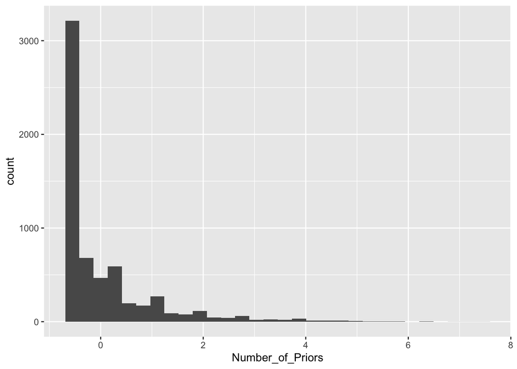

```r
dataset %>% ggplot(aes(x = Number_of_Priors)) + geom_histogram()
```

Instead of a histogram, you can make a density plot with `geom_density()`

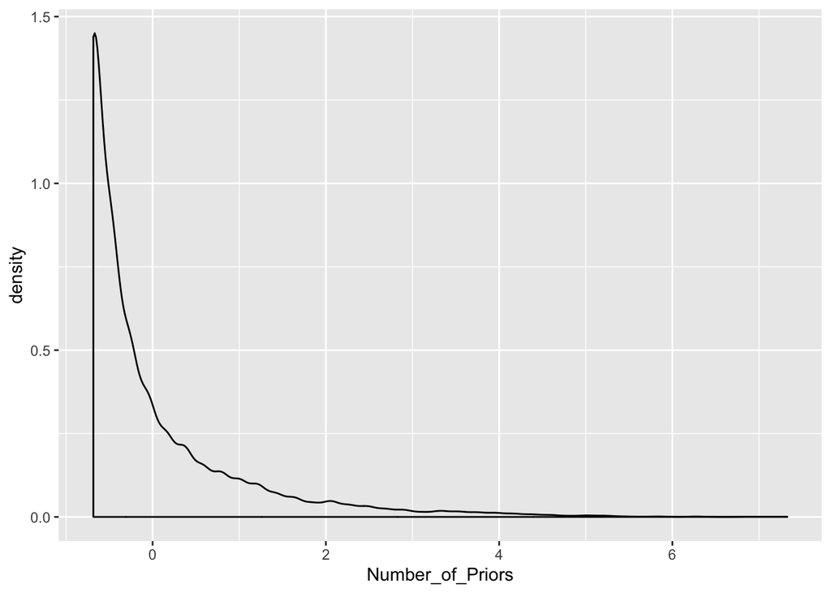

```r
dataset %>% ggplot(aes(x = Number_of_Priors)) + geom_density()
```

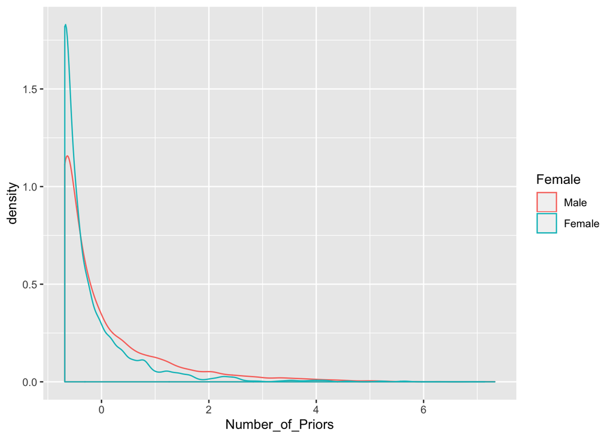

```r
dataset %>%
  ggplot(aes(x = Number_of_Priors, color = Female)) + geom_density()
```

Compare the graph above to the following graph. What changes?

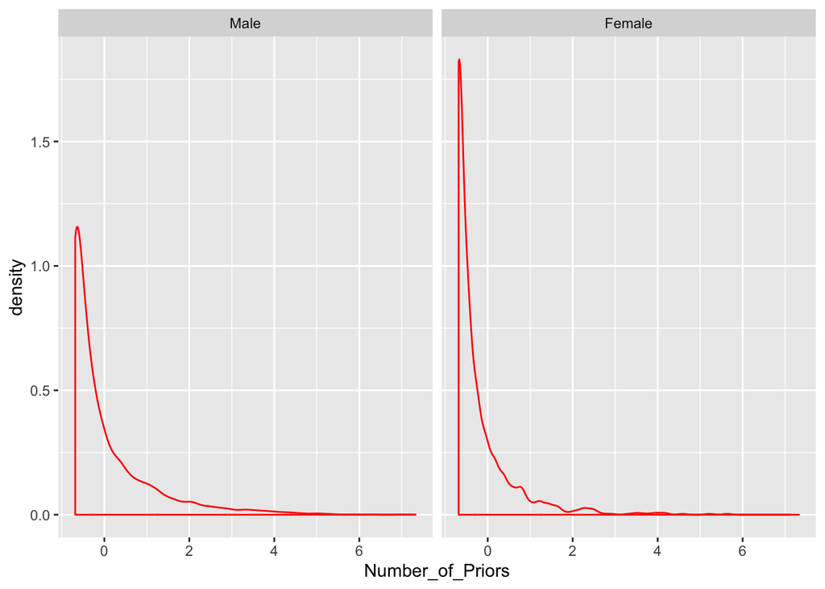

```r
dataset %>%
  ggplot(aes(x = Number_of_Priors)) + geom_density(color = "red") +
  facet_grid(~Female)
```

## Preparing data for regressions

Let’s convert the factor variables into 1/0 dummy variables using the `model.matrix` function that converts a dataframe into matrix ready for regression. Note that we used `.` to ask to use all the variables. Then, we dconvert the matrix back to a dataframe format, drop the intercept variable, and overwrite *dataset* with the resulting output.

```r
model.matrix(~ ., dataset) %>%   as.data.frame() %>% select(-`(Intercept)`) -> dataset
```

```
## select: dropped one variable ((Intercept))
```

```r
str(dataset)
```

```
## 'data.frame':    6172 obs. of  11 variables:
##  $ Two_yr_Recidivismyes     : num  0 1 0 0 0 0 1 1 1 0 ...
##  $ Number_of_Priors         : num  -0.684 2.267 -0.684 -0.684 -0.684 ...
##  $ Age_Above_FourtyFiveyes  : num  0 0 0 0 0 0 0 0 0 0 ...
##  $ Age_Below_TwentyFiveyes  : num  0 0 0 0 0 0 0 0 0 1 ...
##  $ FemaleFemale             : num  0 0 1 0 0 0 0 0 0 1 ...
##  $ Misdemeanoryes           : num  1 0 1 0 1 1 0 0 0 0 ...
##  $ ethnicityAfrican_American: num  0 0 0 1 0 0 1 1 1 1 ...
##  $ ethnicityAsian           : num  0 0 0 0 0 0 0 0 0 0 ...
##  $ ethnicityHispanic        : num  0 0 0 0 1 0 0 0 0 0 ...
##  $ ethnicityNative_American : num  0 0 0 0 0 0 0 0 0 0 ...
##  $ ethnicityOther           : num  1 0 0 0 0 1 0 0 0 0 ...
```

Check: The resulting database should have 6,172 observations and 11 variables. Notice how the names of variables changed after we converted factor variables into numeric.

## Summary statistics

```r
dataset %>%
  select(-Number_of_Priors) %>%
  gather() %>%
  group_by(key) %>% summarise(share = mean(value))
```

```
## select: dropped one variable (Number_of_Priors)
```

```
## gather: reorganized (Two_yr_Recidivismyes, Age_Above_FourtyFiveyes, Age_Below_TwentyFiveyes, FemaleFemale, Misdemeanoryes, …) into (key, value) [was 6172x10, now 61720x2]
```

```
## group_by: one grouping variable (key)
```

```
## summarise: now 10 rows and 2 columns, ungrouped
```

| key | share |
| --- | --- |
| Age_Above_FourtyFiveyes | 0.209494491 |
| Age_Below_TwentyFiveyes | 0.218243681 |
| ethnicityAfrican_American | 0.514419961 |
| ethnicityAsian | 0.005022683 |
| ethnicityHispanic | 0.082469216 |
| ethnicityNative_American | 0.001782242 |
| ethnicityOther | 0.055573558 |
| FemaleFemale | 0.190375891 |
| Misdemeanoryes | 0.356772521 |
| Two_yr_Recidivismyes | 0.455119896 |

```r
# # Alternative code
# dataset %>%
#   select(-Number_of_Priors) %>%
#   summarise_all(list(~mean(.)))
```

The task is to predict the recidivism within the next two years after the arrest

# Ridge regression

First, we will apply ridge regression.

let’s create a grid with penalty parameters, ranging from as high as 10^10 to as small as 0.01.

```r
grid <- 10^seq(10, -2, length = 100)
```

You can quickly visualize penalties by using plot() funciton

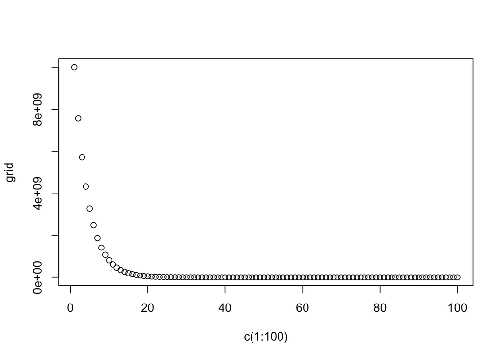

```r
plot(x = c(1:100), y = grid)
```

In R, you can sometimes inspect the inner workings of functions by calling them without parentheses, e.g., `glmnet` instead of `glmnet()`. If you want to inspect what glmnet does, uncomment the code chunk below:

```r
# glmnet
```

But usually it is more convenient to check the help files for the function:

```r
help(glmnet)
```

Unfortunately, the function glmnet does not accept dataframes. It requires `x` to be a matrix, and `y` to be a vector.

Also, we need to create interaction terms, otherwise, it is going to be quite simplistic.

Let’s create matrix `X` and vector `y`

```r
X <- dataset %>% select(-Two_yr_Recidivismyes)
```

```
## select: dropped one variable (Two_yr_Recidivismyes)
```

```r
X <- model.matrix(~ .^2 - 1, X )
y <- dataset$Two_yr_Recidivismyes
```

Let’s fit a ridge regression by setting `alpha = 0` in glmnet. What does `standardize = TRUE` do?

```r
ridge_reg <- glmnet(x = X, y = y, alpha = 0, lambda = grid, standardize = TRUE)
```

There are 56 variables (including interaction terms) and 100 different regressions, one per each value of lambda (the penalty) in our grid vector.

```r
dim(coef(ridge_reg))
```

```
## [1]  56 100
```

Print the first twenty coefficients of ridge regression for the 50th lambda and calculate the l2 norm.

```r
cat("for lambda = ", ridge_reg$lambda[50], " the ridge regression coefficients are: \n")
```

```
## for lambda =  11497.57  the ridge regression coefficients are:
```

```r
coef(ridge_reg)[1:20 , 50]
```

```
##                                (Intercept)
##                               4.551237e-01
##                           Number_of_Priors
##                               6.267850e-06
##                    Age_Above_FourtyFiveyes
##                              -7.392442e-06
##                    Age_Below_TwentyFiveyes
##                               5.797230e-06
##                               FemaleFemale
##                              -5.543036e-06
##                             Misdemeanoryes
##                              -5.417102e-06
##                  ethnicityAfrican_American
##                               6.067206e-06
##                             ethnicityAsian
##                              -8.576726e-06
##                          ethnicityHispanic
##                              -3.955217e-06
##                   ethnicityNative_American
##                              -2.555020e-08
##                             ethnicityOther
##                              -4.291943e-06
##   Number_of_Priors:Age_Above_FourtyFiveyes
##                               5.525473e-06
##   Number_of_Priors:Age_Below_TwentyFiveyes
##                               1.480001e-06
##              Number_of_Priors:FemaleFemale
##                               9.830886e-06
##            Number_of_Priors:Misdemeanoryes
##                               7.671108e-06
## Number_of_Priors:ethnicityAfrican_American
##                               5.576915e-06
##            Number_of_Priors:ethnicityAsian
##                               1.706306e-05
##         Number_of_Priors:ethnicityHispanic
##                               7.563613e-06
##  Number_of_Priors:ethnicityNative_American
##                               6.416715e-06
##            Number_of_Priors:ethnicityOther
##                               9.622764e-06
```

```r
cat("\n\nand the l2 norm is ", sqrt(sum(coef(ridge_reg)[-1,50]^2)), "\n")
```

```
##
##
## and the l2 norm is  6.347954e-05
```

Get l2 norm for all lambdas. What do you observe? Why? (Note: `map()` function comes from [purrr](https://purrr.tidyverse.org/) package)

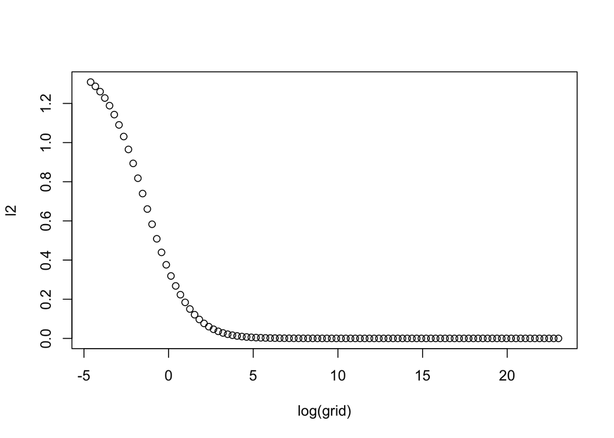

```r
l2 <- map_dbl(c(1:100), ~sqrt(sum(coef(ridge_reg)[-1,.]^2)))
plot(x = log(grid), y = l2)
```

## Train and test samples

Assign half the sample into training set, by creating a vector from 1 to the number of observations and randomly assigning half the vector to train

```r
train <- sample(1:nrow(X), nrow(X)/2)
y_test <- y[-train]
test <- (-train)
```

Rerun ridge regression on the training set

```r
ridge_reg <- glmnet(X[train,], y[train], alpha = 0, lambda = grid, thresh = 1e-12)
```

### Examples lambda = 4 vs lamda = 10^10 vs lambda = 0

## Example 1: lamdba = 4

Predict the recidivism for test sample:

```r
ridge_pred <- predict(ridge_reg, s = 4, newx = X[-train, ])
cat("For lambda = 4, the test MSE equals to ", mean((ridge_pred - y_test)^2))
```

```
## For lambda = 4, the test MSE equals to  0.2331278
```

## Example 2: Test MSE if using only intercept

```r
cat("If we use only an intercept, the test MSE equals to ", mean((mean(y[train]) - y_test)^2))
```

```
## If we use only an intercept, the test MSE equals to  0.2477151
```

This is almost equivalent to using a very large lambda

```r
ridge_pred <- predict(ridge_reg, s = 1e10, newx = X[test, ])
cat("If we use only an intercept, the test MSE equals to ", mean((ridge_pred - y_test)^2))
```

```
## If we use only an intercept, the test MSE equals to  0.2477151
```

## Example 3: OLS

OLS is equivalent to Ridge regression with zero penalty

```r
ridge_pred <- predict(ridge_reg, s = 0, newx = X[test, ])
cat("For lambda = 0 (OLS), the test MSE equals to ", mean((ridge_pred - y_test)^2))
```

```
## For lambda = 0 (OLS), the test MSE equals to  0.2156823
```

## Cross validation to choose the best lambda

```r
cv_out <- cv.glmnet(X[train, ], y[train], alpha = 0)
```

Let’s plot the cros-validation MSE as function of different lambda.

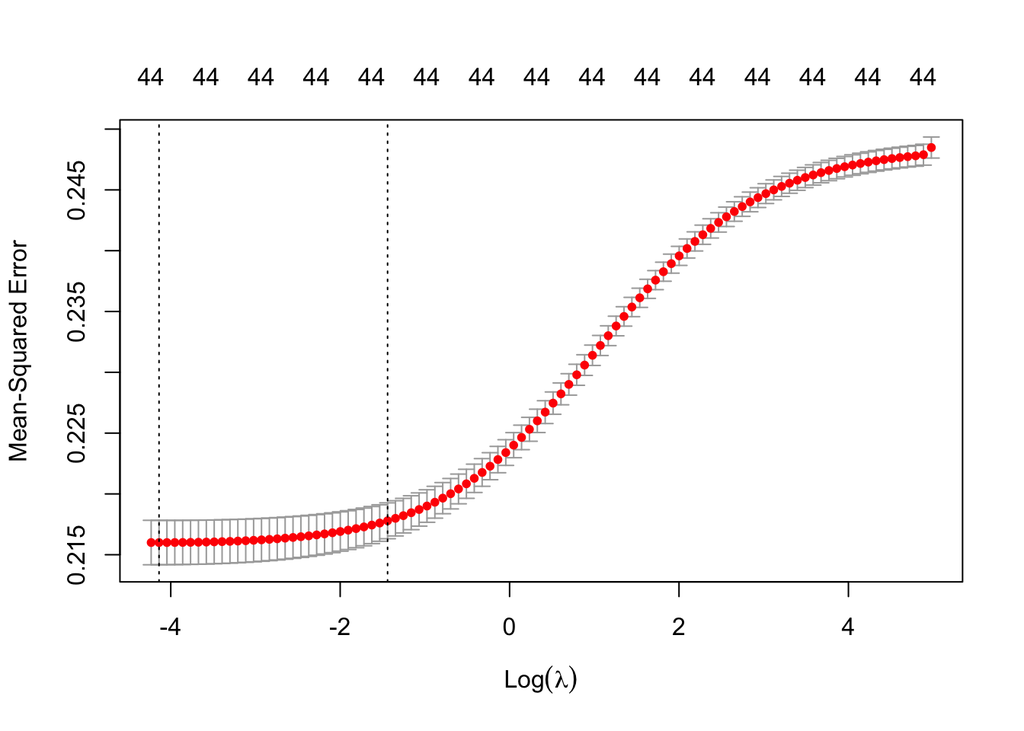

```r
plot(cv_out)
```

The results clearly support using very small penalty on the regression coefficients.

Let’s ask to return the best lamda

```r
bestlam <- cv_out$lambda.min
bestlam
```

```
## [1] 0.01594961
```

```r
ridge_pred <- predict(ridge_reg, s = bestlam, newx = X[test, ])
mean((ridge_pred - y_test)^2)
```

```
## [1] 0.2154088
```

Now use the best lambda for the whole sample. Show the first twenty coefficients

```r
out <- glmnet(X, y, alpha = 0)
predict(out, type = "coefficients", s = bestlam)[1:20,]
```

```
##                                (Intercept)
##                                0.469458211
##                           Number_of_Priors
##                                0.142177001
##                    Age_Above_FourtyFiveyes
##                               -0.148573015
##                    Age_Below_TwentyFiveyes
##                                0.140857774
##                               FemaleFemale
##                                0.020401377
##                             Misdemeanoryes
##                               -0.040026624
##                  ethnicityAfrican_American
##                                0.026960930
##                             ethnicityAsian
##                               -0.088545169
##                          ethnicityHispanic
##                               -0.040855741
##                   ethnicityNative_American
##                               -0.344472079
##                             ethnicityOther
##                               -0.006424355
##   Number_of_Priors:Age_Above_FourtyFiveyes
##                               -0.020461961
##   Number_of_Priors:Age_Below_TwentyFiveyes
##                                0.093221017
##              Number_of_Priors:FemaleFemale
##                                0.052480654
##            Number_of_Priors:Misdemeanoryes
##                                0.016476882
## Number_of_Priors:ethnicityAfrican_American
##                               -0.007328920
##            Number_of_Priors:ethnicityAsian
##                                0.113080111
##         Number_of_Priors:ethnicityHispanic
##                                0.005575586
##  Number_of_Priors:ethnicityNative_American
##                                0.079913889
##            Number_of_Priors:ethnicityOther
##                                0.051450616
```

# Lasso regression

```r
lasso_reg <- glmnet(X[train, ], y[train], alpha = 1,lambda = grid)
```

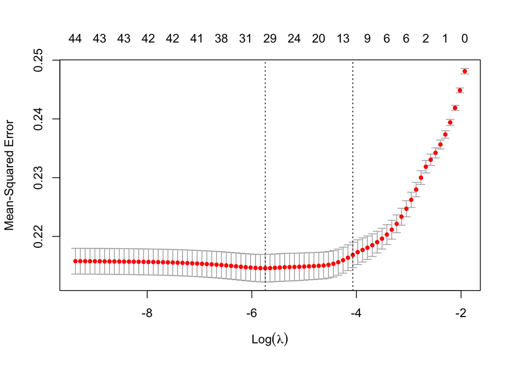

```r
cv_out <- cv.glmnet(X[train,], y[train], alpha = 1)
plot(cv_out)
```

```r
bestlam <- cv_out$lambda.min
lasso_pred <- predict(lasso_reg, s = bestlam, newx = X[test, ])
cat("test MSE for lasso regression is ", mean((lasso_pred - y_test)^2))
```

```
## test MSE for lasso regression is  0.213442
```

Lasso performance in this case is relatively the same as ridge.

```r
out <- glmnet(X, y, alpha = 1, lambda = grid)
lasso_coef <- predict(out, type = "coefficients", s = bestlam)
```

# EXERCISE: write a function that automates the code above

Let’s write a function that would wrap our operations and return the values we want:

- inputs: `grid`, `alpha`, `X_train`, `y_train`, `X_test`, `y_test`
- outputs: `bestlam`, `test_mse`, `coef`

Save the function in a separate file in the folder functions under the name `xval_glmnet_wrapper.R`.

Then load the function (uncomment the code below):

```r
source("functions/xval_glmnet_wrapper.R")
```

Repeat the analysis – ridge and lasso – and save the results

```r
r1_ridge <- xval_glmnet_wrapper(X_train = X[train, ], y_train = y[train], X_test = X[test, ], y_test = y[test], alpha = 0)
```

```
## Performing cross-validationRidge regression
```

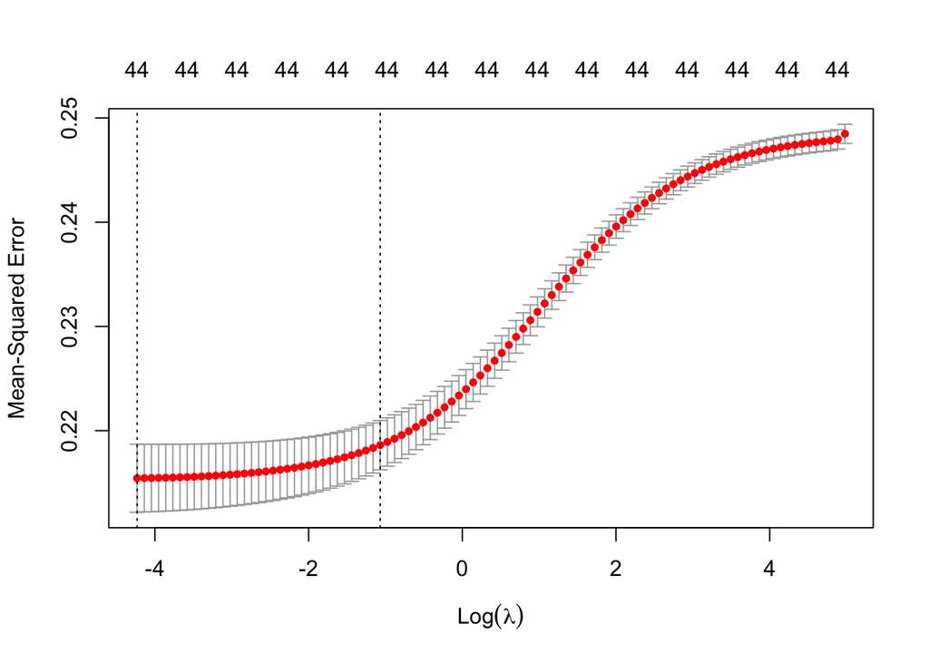

```
## The best lambda is lambda =  0.01453269
## test MSE =  0.2154627
## Compare to test MSE of intercept =  0.2477151 and to test MSE of OLS =  0.2156778
```

```r
r2_lasso <- xval_glmnet_wrapper(X_train = X[train, ], y_train = y[train], X_test = X[test, ], y_test = y[test], alpha = 1)
```

```
## Performing cross-validationLasso regression
```

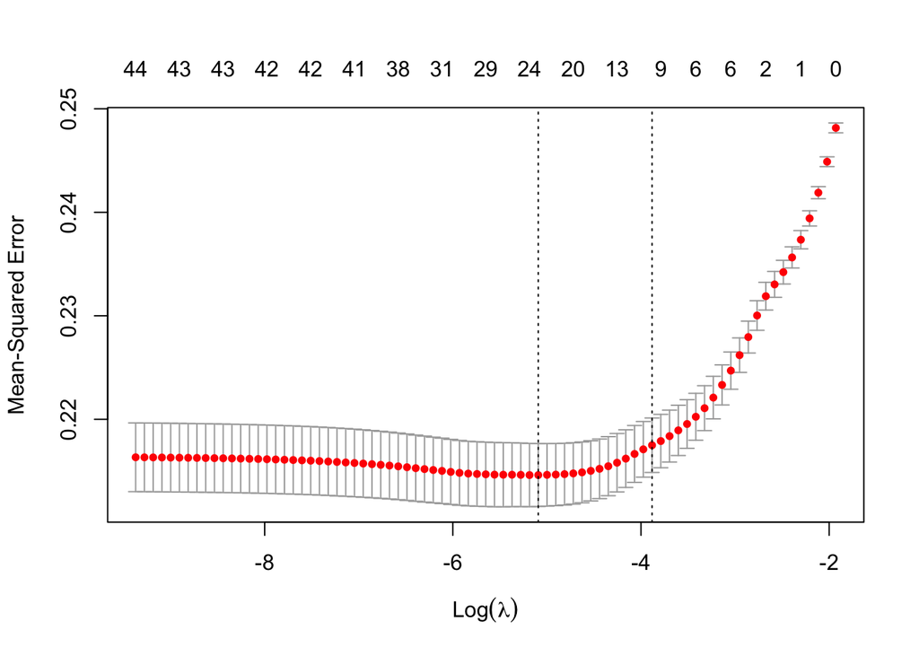

[output not shown]